# Wine Retailer Case Assignment

Yanzi Cai, Ao Zhang, Sizhu Wu, Dong Li, Keyan Wang

### Project Background

- Wine retailer experiment
  - Test setting: email to retailer customers
  - Unit : customer (email address)
  - Treatments: email, holdout
  - Reponse: open, click and 1-month purchase ($)
  - Selection: all active customers
  - Assignment: randomly assigned (1/2 each) to email or control (ctrl)
- Dataset: “data.csv” (total 12 varibles)
  - user_id: user ID
  - group: email ot ctrl
  - respond: includes “open”,“click” and “purch” three columns.
  - kind of wine: includes “chard”, “sav”, “syrah” and “cab” four columns.
  - past_purch: amount of past purchase in dollars.
  - last_purch: days since last purchase.
  - visits: how many times visit

### Analysis task

##### A.Evalute average causal effect.

##### B.Slice and dice analysis to illustrate the potential for targeting on responses for this email campaign.

##### C.“Individual-level” conditional causal effect estimates to be used along with the margin and cost information to score each customer.

##### Set up

```r
#load data
library(dplyr)
library(tidyr)
library(data.table)
library(ggplot2)
library(grf)

data = read.csv("test_data_1904.csv")
data = data[,-2]
summary(data)
```

```
##     user_id          group            open            click
##  Min.   :2000001   ctrl :39156   Min.   :0.0000   Min.   :0.00000
##  1st Qu.:2019579   email:39156   1st Qu.:0.0000   1st Qu.:0.00000
##  Median :2039156                 Median :0.0000   Median :0.00000
##  Mean   :2039156                 Mean   :0.3979   Mean   :0.06729
##  3rd Qu.:2058734                 3rd Qu.:1.0000   3rd Qu.:0.00000
##  Max.   :2078312                 Max.   :1.0000   Max.   :1.00000
##      purch             chard            sav_blanc           syrah
##  Min.   :   0.00   Min.   :    0.00   Min.   :   0.00   Min.   :  0.00
##  1st Qu.:   0.00   1st Qu.:    0.00   1st Qu.:   0.00   1st Qu.:  0.00
##  Median :   0.00   Median :    0.00   Median :   0.00   Median :  0.00
##  Mean   :  13.45   Mean   :   74.01   Mean   :  26.72   Mean   :  2.84
##  3rd Qu.:   0.00   3rd Qu.:   56.62   3rd Qu.:  21.03   3rd Qu.:  0.00
##  Max.   :1812.50   Max.   :13379.44   Max.   :3843.24   Max.   :360.32
##       cab            past_purch         last_purch          visits
##  Min.   :   0.00   Min.   :    0.00   Min.   :   0.00   Min.   : 0.000
##  1st Qu.:   0.00   1st Qu.:    0.00   1st Qu.:  26.00   1st Qu.: 4.000
##  Median :   0.00   Median :   52.95   Median :  63.00   Median : 5.000
##  Mean   :  27.03   Mean   :  130.60   Mean   :  90.06   Mean   : 5.647
##  3rd Qu.:  21.10   3rd Qu.:  169.00   3rd Qu.: 125.00   3rd Qu.: 7.000
##  Max.   :2649.78   Max.   :13379.44   Max.   :1225.00   Max.   :64.000
```

##### Part A. Evalute average causal effect

- Conduct randomization check to make sure the treatment has been randomly assigned to active customers.

```r
#randomization check
lm1 = lm(past_purch~group,data=data)
lm2 = lm(last_purch~group,data=data)
lm3 = lm(visits~group,data=data)
summary(lm1)
```

```
##
## Call:
## lm(formula = past_purch ~ group, data = data)
##
## Residuals:
##     Min      1Q  Median      3Q     Max
##  -131.6  -129.6   -77.7    38.5 13247.8
##
## Coefficients:
##             Estimate Std. Error t value Pr(>|t|)
## (Intercept)  129.581      1.190 108.847   <2e-16 ***
## groupemail     2.035      1.684   1.209    0.227
## ---
## Signif. codes:  0 '***' 0.001 '**' 0.01 '*' 0.05 '.' 0.1 ' ' 1
##
## Residual standard error: 235.6 on 78310 degrees of freedom
## Multiple R-squared:  1.866e-05,  Adjusted R-squared:  5.889e-06
## F-statistic: 1.461 on 1 and 78310 DF,  p-value: 0.2268
```

```r
summary(lm2)
```

```
##
## Call:
## lm(formula = last_purch ~ group, data = data)
##
## Residuals:
##     Min      1Q  Median      3Q     Max
##  -90.15  -64.15  -27.15   34.85 1135.04
##
## Coefficients:
##             Estimate Std. Error t value Pr(>|t|)
## (Intercept)  90.1548     0.4547 198.275   <2e-16 ***
## groupemail   -0.1937     0.6430  -0.301    0.763
## ---
## Signif. codes:  0 '***' 0.001 '**' 0.01 '*' 0.05 '.' 0.1 ' ' 1
##
## Residual standard error: 89.97 on 78310 degrees of freedom
## Multiple R-squared:  1.159e-06,  Adjusted R-squared:  -1.161e-05
## F-statistic: 0.09073 on 1 and 78310 DF,  p-value: 0.7633
```

```r
summary(lm3)
```

```
##
## Call:
## lm(formula = visits ~ group, data = data)
##
## Residuals:
##    Min     1Q Median     3Q    Max
## -5.649 -1.649 -0.645  1.355 58.355
##
## Coefficients:
##              Estimate Std. Error t value Pr(>|t|)
## (Intercept)  5.648534   0.013336 423.560   <2e-16 ***
## groupemail  -0.003218   0.018860  -0.171    0.865
## ---
## Signif. codes:  0 '***' 0.001 '**' 0.01 '*' 0.05 '.' 0.1 ' ' 1
##
## Residual standard error: 2.639 on 78310 degrees of freedom
## Multiple R-squared:  3.718e-07,  Adjusted R-squared:  -1.24e-05
## F-statistic: 0.02911 on 1 and 78310 DF,  p-value: 0.8645
```

```r
#average causal effect
lm = lm(purch~group,data=data)
summary(lm)
```

```
##
## Call:
## lm(formula = purch ~ group, data = data)
##
## Residuals:
##     Min      1Q  Median      3Q     Max
##  -14.12  -14.12  -12.77  -12.77 1798.38
##
## Coefficients:
##             Estimate Std. Error t value Pr(>|t|)
## (Intercept)  12.7727     0.2260  56.528  < 2e-16 ***
## groupemail    1.3465     0.3195   4.214 2.52e-05 ***
## ---
## Signif. codes:  0 '***' 0.001 '**' 0.01 '*' 0.05 '.' 0.1 ' ' 1
##
## Residual standard error: 44.71 on 78310 degrees of freedom
## Multiple R-squared:  0.0002267,  Adjusted R-squared:  0.0002139
## F-statistic: 17.76 on 1 and 78310 DF,  p-value: 2.515e-05
```

- Results interpretation:
  - The treatment is randomly assigned.
  - The coefficient of “groupemail” is 1.3465, which means, the average causal effect of this email campaign can be interpreted as: customers who received email (treatment group) will purchase $1.3465 more than customers who didn’t receive email (ctrl group).

##### Part B. Slice and Dice Analysis

- For each variable, identify the best cutoff point, where each variable has a significant impact on purchase decision seperately.

```r
cutoff = as.data.frame(matrix(0,7,3))
colnames(cutoff) = c("variable","p-value","number")

#past purchase
num = seq(0,170,5)
dataTry = data
num2 = 1:35
for (i in 1:35){
  dataTry$pastPurch = (data$past_purch > num[i])
  lm = summary(lm(purch~group*pastPurch,data=dataTry))
  num2[i] = lm$coefficients[4,4]
  cutoff[1,1] = "past purchase"
  cutoff[1,2] = num2[which.min(num2)]
  cutoff[1,3] = num[which.min(num2)] #160
  finalPos = which.min(num2)
}
summary(lm(purch~group*(last_purch<160),data=dataTry))
```

```
##
## Call:
## lm(formula = purch ~ group * (last_purch < 160), data = dataTry)
##
## Residuals:
##     Min      1Q  Median      3Q     Max
##  -16.51  -16.51  -14.87   -2.43 1795.99
##
## Coefficients:
##                                 Estimate Std. Error t value Pr(>|t|)
## (Intercept)                       2.5357     0.5441   4.661 3.16e-06 ***
## groupemail                       -0.1065     0.7701  -0.138   0.8900
## last_purch < 160TRUE             12.3388     0.5973  20.657  < 2e-16 ***
## groupemail:last_purch < 160TRUE   1.7417     0.8453   2.060   0.0394 *
## ---
## Signif. codes:  0 '***' 0.001 '**' 0.01 '*' 0.05 '.' 0.1 ' ' 1
##
## Residual standard error: 44.43 on 78308 degrees of freedom
## Multiple R-squared:  0.0126, Adjusted R-squared:  0.01256
## F-statistic:   333 on 3 and 78308 DF,  p-value: < 2.2e-16
```

```r
summary(lm(purch~(last_purch<160)+group:(last_purch<160),data=dataTry))
```

```
##
## Call:
## lm(formula = purch ~ (last_purch < 160) + group:(last_purch <
##     160), data = dataTry)
##
## Residuals:
##     Min      1Q  Median      3Q     Max
##  -16.51  -16.51  -14.87   -2.43 1795.99
##
## Coefficients:
##                                  Estimate Std. Error t value Pr(>|t|)
## (Intercept)                        2.5357     0.5441   4.661 3.16e-06 ***
## last_purch < 160TRUE              12.3388     0.5973  20.657  < 2e-16 ***
## last_purch < 160FALSE:groupemail  -0.1065     0.7701  -0.138     0.89
## last_purch < 160TRUE:groupemail    1.6353     0.3486   4.691 2.72e-06 ***
## ---
## Signif. codes:  0 '***' 0.001 '**' 0.01 '*' 0.05 '.' 0.1 ' ' 1
##
## Residual standard error: 44.43 on 78308 degrees of freedom
## Multiple R-squared:  0.0126, Adjusted R-squared:  0.01256
## F-statistic:   333 on 3 and 78308 DF,  p-value: < 2.2e-16
```

```r
#recent purchase(*)
num = seq(10,100,5)
num2 = 1:19
for (i in 1:19){
  dataTry$recentPurch = (data$last_purch < num[i])
  lm = summary(lm(purch~group*recentPurch,data=dataTry))
  num2[i] = lm$coefficients[4,4]
  cutoff[2,1] = "recent purchase"
  cutoff[2,2] = num2[which.min(num2)]
  cutoff[2,3] = num[which.min(num2)] #35
  finalPos = which.min(num2)
}
summary(lm(purch~group*(last_purch<35),data=dataTry))
```

```
##
## Call:
## lm(formula = purch ~ group * (last_purch < 35), data = dataTry)
##
## Residuals:
##     Min      1Q  Median      3Q     Max
##  -23.06   -9.93   -9.93   -9.20 1802.57
##
## Coefficients:
##                                Estimate Std. Error t value Pr(>|t|)
## (Intercept)                      9.1999     0.2713  33.912  < 2e-16 ***
## groupemail                       0.7312     0.3839   1.905  0.05680 .
## last_purch < 35TRUE             11.2520     0.4814  23.372  < 2e-16 ***
## groupemail:last_purch < 35TRUE   1.8753     0.6804   2.756  0.00585 **
## ---
## Signif. codes:  0 '***' 0.001 '**' 0.01 '*' 0.05 '.' 0.1 ' ' 1
##
## Residual standard error: 44.35 on 78308 degrees of freedom
## Multiple R-squared:  0.01645,    Adjusted R-squared:  0.01641
## F-statistic: 436.5 on 3 and 78308 DF,  p-value: < 2.2e-16
```

```r
summary(lm(purch~(last_purch<35)+group:(last_purch<35),data=dataTry))
```

```
##
## Call:
## lm(formula = purch ~ (last_purch < 35) + group:(last_purch <
##     35), data = dataTry)
##
## Residuals:
##     Min      1Q  Median      3Q     Max
##  -23.06   -9.93   -9.93   -9.20 1802.57
##
## Coefficients:
##                                 Estimate Std. Error t value Pr(>|t|)
## (Intercept)                       9.1999     0.2713  33.912  < 2e-16 ***
## last_purch < 35TRUE              11.2520     0.4814  23.372  < 2e-16 ***
## last_purch < 35FALSE:groupemail   0.7312     0.3839   1.905   0.0568 .
## last_purch < 35TRUE:groupemail    2.6066     0.5618   4.640  3.5e-06 ***
## ---
## Signif. codes:  0 '***' 0.001 '**' 0.01 '*' 0.05 '.' 0.1 ' ' 1
##
## Residual standard error: 44.35 on 78308 degrees of freedom
## Multiple R-squared:  0.01645,    Adjusted R-squared:  0.01641
## F-statistic: 436.5 on 3 and 78308 DF,  p-value: < 2.2e-16
```

```r
#visits(*)
num = seq(1,35,1)
num2 = 1:35
for (i in 1:35){
  dataTry$visit = (data$visits > num[i])
  lm = summary(lm(purch~group*visit,data=dataTry))
  num2[i] = lm$coefficients[4,4]
  cutoff[3,1] = "visits"
  cutoff[3,2] = num2[which.min(num2)]
  cutoff[3,3] = num[which.min(num2)] #15
  finalPos = which.min(num2)
}
summary(lm(purch~group*(visits>15),data=data))
```

```
##
## Call:
## lm(formula = purch ~ group * (visits > 15), data = data)
##
## Residuals:
##     Min      1Q  Median      3Q     Max
##  -62.81  -13.94  -12.65  -12.65 1798.56
##
## Coefficients:
##                            Estimate Std. Error t value Pr(>|t|)
## (Intercept)                 12.6510     0.2260  55.988  < 2e-16 ***
## groupemail                   1.2896     0.3196   4.035 5.46e-05 ***
## visits > 15TRUE             36.6319     3.9216   9.341  < 2e-16 ***
## groupemail:visits > 15TRUE  12.2413     5.4189   2.259   0.0239 *
## ---
## Signif. codes:  0 '***' 0.001 '**' 0.01 '*' 0.05 '.' 0.1 ' ' 1
##
## Residual standard error: 44.64 on 78308 degrees of freedom
## Multiple R-squared:  0.00351,    Adjusted R-squared:  0.003472
## F-statistic: 91.95 on 3 and 78308 DF,  p-value: < 2.2e-16
```

```r
summary(lm(purch~(visits>15)+group:(visits>15),data=dataTry))
```

```
##
## Call:
## lm(formula = purch ~ (visits > 15) + group:(visits > 15), data = dataTry)
##
## Residuals:
##     Min      1Q  Median      3Q     Max
##  -62.81  -13.94  -12.65  -12.65 1798.56
##
## Coefficients:
##                             Estimate Std. Error t value Pr(>|t|)
## (Intercept)                  12.6510     0.2260  55.988  < 2e-16 ***
## visits > 15TRUE              36.6319     3.9216   9.341  < 2e-16 ***
## visits > 15FALSE:groupemail   1.2896     0.3196   4.035 5.46e-05 ***
## visits > 15TRUE:groupemail   13.5309     5.4094   2.501   0.0124 *
## ---
## Signif. codes:  0 '***' 0.001 '**' 0.01 '*' 0.05 '.' 0.1 ' ' 1
##
## Residual standard error: 44.64 on 78308 degrees of freedom
## Multiple R-squared:  0.00351,    Adjusted R-squared:  0.003472
## F-statistic: 91.95 on 3 and 78308 DF,  p-value: < 2.2e-16
```

```r
#chard
num = seq(1,200,5)
num2 = 1:40
for (i in 1:40){
  dataTry$anyChard = (data$chard > num[i])
  lm = summary(lm(purch~group*anyChard,data=dataTry))
  num2[i] = lm$coefficients[4,4]
  cutoff[4,1] = "chard"
  cutoff[4,2] = num2[which.min(num2)]
  cutoff[4,3] = num[which.min(num2)] #156
  finalPos = which.min(num2)
}
summary(lm(purch~group*(chard>156),data=dataTry))
```

```
##
## Call:
## lm(formula = purch ~ group * (chard > 156), data = dataTry)
##
## Residuals:
##     Min      1Q  Median      3Q     Max
##  -30.12  -11.39  -10.43  -10.43 1801.11
##
## Coefficients:
##                            Estimate Std. Error t value Pr(>|t|)
## (Intercept)                 10.4250     0.2417  43.129   <2e-16 ***
## groupemail                   0.9649     0.3421   2.820   0.0048 **
## chard > 156TRUE             16.4267     0.6394  25.691   <2e-16 ***
## groupemail:chard > 156TRUE   2.3082     0.9007   2.563   0.0104 *
## ---
## Signif. codes:  0 '***' 0.001 '**' 0.01 '*' 0.05 '.' 0.1 ' ' 1
##
## Residual standard error: 44.28 on 78308 degrees of freedom
## Multiple R-squared:  0.01941,    Adjusted R-squared:  0.01938
## F-statistic: 516.8 on 3 and 78308 DF,  p-value: < 2.2e-16
```

```r
summary(lm(purch~(chard>156)+group:(chard>156),data=dataTry))
```

```
##
## Call:
## lm(formula = purch ~ (chard > 156) + group:(chard > 156), data = dataTry)
##
## Residuals:
##     Min      1Q  Median      3Q     Max
##  -30.12  -11.39  -10.43  -10.43 1801.11
##
## Coefficients:
##                             Estimate Std. Error t value Pr(>|t|)
## (Intercept)                  10.4250     0.2417  43.129  < 2e-16 ***
## chard > 156TRUE              16.4267     0.6394  25.691  < 2e-16 ***
## chard > 156FALSE:groupemail   0.9649     0.3421   2.820   0.0048 **
## chard > 156TRUE:groupemail    3.2731     0.8332   3.929 8.55e-05 ***
## ---
## Signif. codes:  0 '***' 0.001 '**' 0.01 '*' 0.05 '.' 0.1 ' ' 1
##
## Residual standard error: 44.28 on 78308 degrees of freedom
## Multiple R-squared:  0.01941,    Adjusted R-squared:  0.01938
## F-statistic: 516.8 on 3 and 78308 DF,  p-value: < 2.2e-16
```

```r
#sav(*)
num = seq(1,30,1)
num2 = 1:30
for (i in 1:30){
  dataTry$anySav = (data$sav_blanc > num[i])
  lm = summary(lm(purch~group*anySav,data=dataTry))
  num2[i] = lm$coefficients[4,4]
  cutoff[5,1] = "sav"
  cutoff[5,2] = num2[which.min(num2)]
  cutoff[5,3] = num[which.min(num2)] #13
  finalPos = which.min(num2)
}
summary(lm(purch~group*(sav_blanc>13),data=dataTry))
```

```
##
## Call:
## lm(formula = purch ~ group * (sav_blanc > 13), data = dataTry)
##
## Residuals:
##     Min      1Q  Median      3Q     Max
##  -17.86  -12.68  -11.96  -11.96 1794.64
##
## Coefficients:
##                               Estimate Std. Error t value Pr(>|t|)
## (Intercept)                    11.9568     0.2654  45.047  < 2e-16 ***
## groupemail                      0.7203     0.3756   1.918  0.05514 .
## sav_blanc > 13TRUE              2.9498     0.5047   5.845 5.09e-09 ***
## groupemail:sav_blanc > 13TRUE   2.2329     0.7131   3.131  0.00174 **
## ---
## Signif. codes:  0 '***' 0.001 '**' 0.01 '*' 0.05 '.' 0.1 ' ' 1
##
## Residual standard error: 44.67 on 78308 degrees of freedom
## Multiple R-squared:  0.002011,   Adjusted R-squared:  0.001973
## F-statistic:  52.6 on 3 and 78308 DF,  p-value: < 2.2e-16
```

```r
summary(lm(purch~(sav_blanc>13)+group:(sav_blanc>13),data=dataTry))
```

```
##
## Call:
## lm(formula = purch ~ (sav_blanc > 13) + group:(sav_blanc > 13),
##     data = dataTry)
##
## Residuals:
##     Min      1Q  Median      3Q     Max
##  -17.86  -12.68  -11.96  -11.96 1794.64
##
## Coefficients:
##                                Estimate Std. Error t value Pr(>|t|)
## (Intercept)                     11.9568     0.2654  45.047  < 2e-16 ***
## sav_blanc > 13TRUE               2.9498     0.5047   5.845 5.09e-09 ***
## sav_blanc > 13FALSE:groupemail   0.7203     0.3756   1.918   0.0551 .
## sav_blanc > 13TRUE:groupemail    2.9532     0.6062   4.872 1.11e-06 ***
## ---
## Signif. codes:  0 '***' 0.001 '**' 0.01 '*' 0.05 '.' 0.1 ' ' 1
##
## Residual standard error: 44.67 on 78308 degrees of freedom
## Multiple R-squared:  0.002011,   Adjusted R-squared:  0.001973
## F-statistic:  52.6 on 3 and 78308 DF,  p-value: < 2.2e-16
```

```r
#syrah (*)
num = seq(50,110,5)
num2 = 1:length(num)
for (i in 1:length(num2)){
  dataTry$anySyr = (data$syrah > num[i])
  lm = summary(lm(purch~group*anySyr,data=dataTry))
  num2[i] = lm$coefficients[4,4]
  cutoff[6,1] = "syrah"
  cutoff[6,2] = num2[which.min(num2)]
  cutoff[6,3] = num[which.min(num2)] #75
  finalPos = which.min(num2)
}
summary(lm(purch~group*(syrah<75),data=dataTry))
```

```
##
## Call:
## lm(formula = purch ~ group * (syrah < 75), data = dataTry)
##
## Residuals:
##     Min      1Q  Median      3Q     Max
##  -25.80  -14.11  -12.73  -12.73 1798.39
##
## Coefficients:
##                           Estimate Std. Error t value Pr(>|t|)
## (Intercept)                 25.798      3.952   6.528 6.69e-11 ***
## groupemail                  -8.999      5.546  -1.623 0.104679
## syrah < 75TRUE             -13.068      3.958  -3.302 0.000962 ***
## groupemail:syrah < 75TRUE   10.379      5.555   1.868 0.061719 .
## ---
## Signif. codes:  0 '***' 0.001 '**' 0.01 '*' 0.05 '.' 0.1 ' ' 1
##
## Residual standard error: 44.71 on 78308 degrees of freedom
## Multiple R-squared:  0.0003719,  Adjusted R-squared:  0.0003336
## F-statistic: 9.711 on 3 and 78308 DF,  p-value: 2.105e-06
```

```r
summary(lm(purch~(syrah<75)+group:(syrah<75),data=dataTry))
```

```
##
## Call:
## lm(formula = purch ~ (syrah < 75) + group:(syrah < 75), data = dataTry)
##
## Residuals:
##     Min      1Q  Median      3Q     Max
##  -25.80  -14.11  -12.73  -12.73 1798.39
##
## Coefficients:
##                            Estimate Std. Error t value Pr(>|t|)
## (Intercept)                 25.7980     3.9517   6.528 6.69e-11 ***
## syrah < 75TRUE             -13.0681     3.9582  -3.302 0.000962 ***
## syrah < 75FALSE:groupemail  -8.9991     5.5461  -1.623 0.104679
## syrah < 75TRUE:groupemail    1.3801     0.3201   4.312 1.62e-05 ***
## ---
## Signif. codes:  0 '***' 0.001 '**' 0.01 '*' 0.05 '.' 0.1 ' ' 1
##
## Residual standard error: 44.71 on 78308 degrees of freedom
## Multiple R-squared:  0.0003719,  Adjusted R-squared:  0.0003336
## F-statistic: 9.711 on 3 and 78308 DF,  p-value: 2.105e-06
```

```r
#cab(*)
num = seq(100,500,5)
num2 = 1:81
for (i in 1:81){
  dataTry$anyCab = (data$cab > num[i])
  lm = summary(lm(purch~group*anyCab,data=dataTry))
  num2[i] = lm$coefficients[4,4]
  cutoff[7,1] = "cab"
  cutoff[7,2] = num2[which.min(num2)]
  cutoff[7,3] = num[which.min(num2)] #230
  finalPos = which.min(num2)
}
summary(lm(purch~(cab>230)+group:(cab>230),data=dataTry))
```

```
##
## Call:
## lm(formula = purch ~ (cab > 230) + group:(cab > 230), data = dataTry)
##
## Residuals:
##     Min      1Q  Median      3Q     Max
##  -31.27  -13.72  -12.38  -12.38 1798.78
##
## Coefficients:
##                           Estimate Std. Error t value Pr(>|t|)
## (Intercept)                12.3825     0.2282   54.26  < 2e-16 ***
## cab > 230TRUE              17.0509     1.5086   11.30  < 2e-16 ***
## cab > 230FALSE:groupemail   1.3328     0.3227    4.13 3.64e-05 ***
## cab > 230TRUE:groupemail    1.8330     2.1060    0.87    0.384
## ---
## Signif. codes:  0 '***' 0.001 '**' 0.01 '*' 0.05 '.' 0.1 ' ' 1
##
## Residual standard error: 44.64 on 78308 degrees of freedom
## Multiple R-squared:  0.003584,   Adjusted R-squared:  0.003546
## F-statistic: 93.89 on 3 and 78308 DF,  p-value: < 2.2e-16
```

```r
summary(lm(purch~group*(cab>230),data=dataTry))
```

```
##
## Call:
## lm(formula = purch ~ group * (cab > 230), data = dataTry)
##
## Residuals:
##     Min      1Q  Median      3Q     Max
##  -31.27  -13.72  -12.38  -12.38 1798.78
##
## Coefficients:
##                          Estimate Std. Error t value Pr(>|t|)
## (Intercept)               12.3825     0.2282  54.261  < 2e-16 ***
## groupemail                 1.3328     0.3227   4.130 3.64e-05 ***
## cab > 230TRUE             17.0509     1.5086  11.303  < 2e-16 ***
## groupemail:cab > 230TRUE   0.5002     2.1306   0.235    0.814
## ---
## Signif. codes:  0 '***' 0.001 '**' 0.01 '*' 0.05 '.' 0.1 ' ' 1
##
## Residual standard error: 44.64 on 78308 degrees of freedom
## Multiple R-squared:  0.003584,   Adjusted R-squared:  0.003546
## F-statistic: 93.89 on 3 and 78308 DF,  p-value: < 2.2e-16
```

```r
# show all best cutoff point
cutoff
```

```
##          variable     p-value number
## 1   past purchase 0.020782241    160
## 2 recent purchase 0.005851061     35
## 3          visits 0.023885208     15
## 4           chard 0.010385806    156
## 5             sav 0.001741254     13
## 6           syrah 0.061719149     75
## 7             cab 0.023383143    350
```

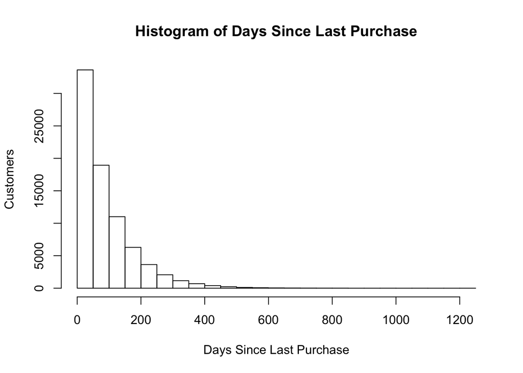

```r
# plot the result of the most significate variable "last_purch"
hist(data$last_purch,
     xlab="Days Since Last Purchase", ylab="Customers",
     main="Histogram of Days Since Last Purchase")
```

```r
dataPic = data.table(dataTry)
datagg = dataPic[,.(open = mean(open), click=mean(click), purch = mean(purch),seOpen = sd(open)/sqrt(.N), seClick=sd(click)/sqrt(.N), sePurch = sd(purch)/sqrt(.N),.N),by = .(group,recentPurch)]
datagg
```

```
##    group recentPurch      open     click     purch      seOpen     seClick
## 1: email       FALSE 0.6147043 0.1088210  4.792423 0.004268007 0.002731076
## 2:  ctrl        TRUE 0.0000000 0.0000000 16.947597 0.000000000 0.000000000
## 3: email        TRUE 0.8858257 0.1474018 18.756276 0.001966554 0.002192155
## 4:  ctrl       FALSE 0.0000000 0.0000000  4.395867 0.000000000 0.000000000
##      sePurch     N
## 1: 0.2412245 13003
## 2: 0.3048933 26132
## 3: 0.3238873 26153
## 4: 0.2228580 13024
```

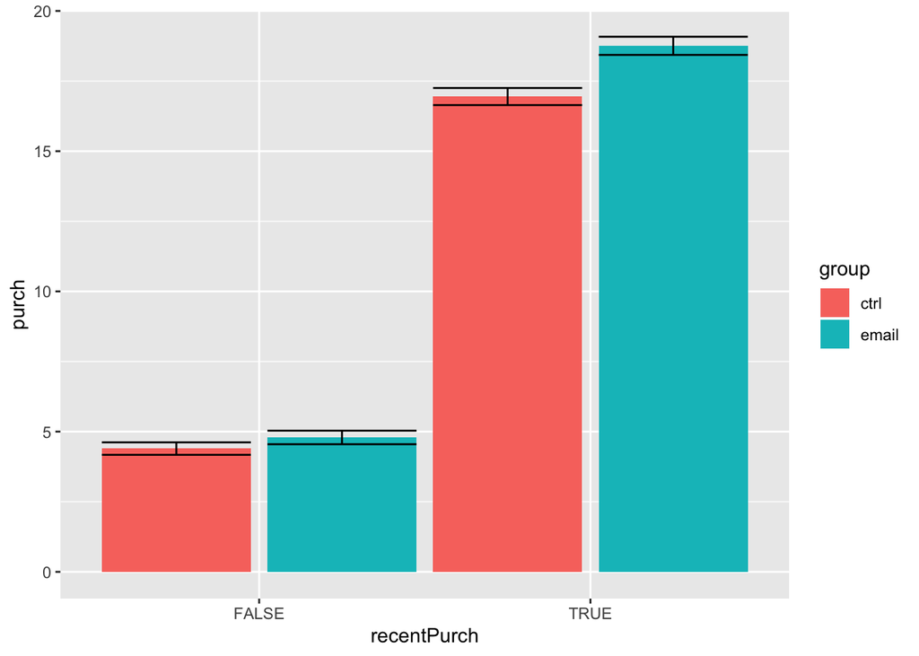

```r
dodge = position_dodge(width=1)
ggplot(aes(fill=group,y=purch,x=recentPurch,ymax=purch+sePurch,ymin=purch-sePurch),data=datagg)+
  geom_bar(position=dodge,stat="identity") +
  geom_errorbar(position=dodge)
```

```r
labs(x="Group",y="Purchases")
```

```
## $x
## [1] "Group"
##
## $y
## [1] "Purchases"
##
## attr(,"class")
## [1] "labels"
```

- Results interpretation
  - Recent buyers(days since last purchase <35 days) can increase the overall purchase power by 58%, email effect by 2% and email effect size by 90%.

##### Part C. “Individual-level” conditional causal effect

- Tune causal forest model using training dataset.
- Predict the purchase of training sample by applying tuned causal forest model.
- Calculate profits by comparing lift value(how much email can increase purchase) with cost to determine target group.

```r
#causal forest
treat <- as.character(data$group)
for (i in 1:78312){
  if (treat[i]=="ctrl"){
    treat[i]=FALSE
  }else{
    treat[i]=TRUE
  }
}
treat = as.logical(treat)
response <- data$purch
baseline <- data[, c("user_id","last_purch","visits","sav_blanc","syrah","cab","chard")]
tmp=proc.time()[3]
cf <- causal_forest(baseline[,-1], response, treat)
tmp = proc.time()[3]-tmp
print(cf)
```

```
## GRF forest object of type causal_forest
## Number of trees: 2000
## Number of training samples: 78312
## Variable importance:
##     1     2     3     4     5     6
## 0.217 0.046 0.251 0.059 0.129 0.298
```

```r
average_treatment_effect(cf, method="AIPW")
```

```
##  estimate   std.err
## 1.3184009 0.3094199
```

```r
base = baseline
vec=predict(cf, base[,-1])
base$lift = 0
for (i in 1:78312){
  base$lift[i] = vec[i,1]
}


base$target = 0
for (i in 1:78312){
  if (base$lift[i]*0.3-0.1>0){
    base$target[i] = 1
  }
}

#target info
sampleSize = sum(base$target)/length(base$target)
sampleSize
```

```
## [1] 0.5489325
```

```r
dataNew = merge(base,data,on="user_id",all=FALSE)
summary(dataNew[dataNew$target == 1,])
```

```
##     user_id          last_purch       visits         sav_blanc
##  Min.   :2000001   Min.   :   0   Min.   : 0.000   Min.   :   0.00
##  1st Qu.:2019372   1st Qu.:  23   1st Qu.: 4.000   1st Qu.:   0.00
##  Median :2039002   Median :  53   Median : 5.000   Median :   0.00
##  Mean   :2039061   Mean   :  73   Mean   : 5.661   Mean   :  28.01
##  3rd Qu.:2058695   3rd Qu.: 101   3rd Qu.: 7.000   3rd Qu.:  33.68
##  Max.   :2078312   Max.   :1054   Max.   :64.000   Max.   :2857.50
##      syrah              cab              chard               lift
##  Min.   :  0.000   Min.   :   0.00   Min.   :    0.00   Min.   : 0.3334
##  1st Qu.:  0.000   1st Qu.:   0.00   1st Qu.:    0.00   1st Qu.: 1.4982
##  Median :  0.000   Median :   0.00   Median :    0.00   Median : 3.0770
##  Mean   :  2.228   Mean   :  30.39   Mean   :   93.38   Mean   : 4.1155
##  3rd Qu.:  0.000   3rd Qu.:  29.59   3rd Qu.:   75.48   3rd Qu.: 5.5767
##  Max.   :261.560   Max.   :1826.31   Max.   :13379.44   Max.   :62.5888
##      target    group            open            click
##  Min.   :1   ctrl :21540   Min.   :0.0000   Min.   :0.00000
##  1st Qu.:1   email:21448   1st Qu.:0.0000   1st Qu.:0.00000
##  Median :1                 Median :0.0000   Median :0.00000
##  Mean   :1                 Mean   :0.4234   Mean   :0.07688
##  3rd Qu.:1                 3rd Qu.:1.0000   3rd Qu.:0.00000
##  Max.   :1                 Max.   :1.0000   Max.   :1.00000
##      purch            past_purch
##  Min.   :   0.000   Min.   :    0.00
##  1st Qu.:   0.000   1st Qu.:    0.00
##  Median :   0.000   Median :   66.41
##  Mean   :  15.015   Mean   :  154.02
##  3rd Qu.:   4.825   3rd Qu.:  200.82
##  Max.   :1812.500   Max.   :13379.44
```

```r
summary(dataNew[dataNew$target == 0,])
```

```
##     user_id          last_purch         visits        sav_blanc
##  Min.   :2000005   Min.   :   0.0   Min.   : 0.00   Min.   :   0.00
##  1st Qu.:2019855   1st Qu.:  34.0   1st Qu.: 4.00   1st Qu.:   0.00
##  Median :2039360   Median :  80.0   Median : 5.00   Median :   0.00
##  Mean   :2039272   Mean   : 110.8   Mean   : 5.63   Mean   :  25.14
##  3rd Qu.:2058764   3rd Qu.: 164.0   3rd Qu.: 7.00   3rd Qu.:   0.00
##  Max.   :2078309   Max.   :1225.0   Max.   :33.00   Max.   :3843.24
##      syrah              cab              chard              lift
##  Min.   :  0.000   Min.   :   0.00   Min.   :   0.00   Min.   :-38.2467
##  1st Qu.:  0.000   1st Qu.:   0.00   1st Qu.:   0.00   1st Qu.: -3.1227
##  Median :  0.000   Median :   0.00   Median :   0.00   Median : -1.2428
##  Mean   :  3.585   Mean   :  22.93   Mean   :  50.44   Mean   : -2.1998
##  3rd Qu.:  0.000   3rd Qu.:   0.00   3rd Qu.:  34.29   3rd Qu.: -0.2411
##  Max.   :360.320   Max.   :2649.78   Max.   :5118.16   Max.   :  0.3333
##      target    group            open            click
##  Min.   :0   ctrl :17616   Min.   :0.0000   Min.   :0.00000
##  1st Qu.:0   email:17708   1st Qu.:0.0000   1st Qu.:0.00000
##  Median :0                 Median :0.0000   Median :0.00000
##  Mean   :0                 Mean   :0.3668   Mean   :0.05563
##  3rd Qu.:0                 3rd Qu.:1.0000   3rd Qu.:0.00000
##  Max.   :0                 Max.   :1.0000   Max.   :1.00000
##      purch           past_purch
##  Min.   :   0.00   Min.   :   0.00
##  1st Qu.:   0.00   1st Qu.:   0.00
##  Median :   0.00   Median :  38.91
##  Mean   :  11.54   Mean   : 102.10
##  3rd Qu.:   0.00   3rd Qu.: 134.79
##  Max.   :1158.09   Max.   :5353.42
```

```r
#predict new dataset
#base = newdata[, c("user_id","last_purch","visits","sav_blanc","syrah","cab","chard")]
#vec=predict(cf, base[,-1])
#base$lift = 0
#for (i in 1:78312){base$lift[i] = vec[i,1]}
#base$target = 0
#for (i in 1:78312){if (base$lift[i]*0.3-0.1>0){base$target[i] = 1}}
```